# Discografía Charly Garcia

Grupo 3

2022-12-08

MAESTRÍA EN CIENCIA DE DATOS

UNIVERSIDAD AUSTRAL

ASIGNATURA: Análisis Inteligente de Datos

GRUPO 3. TP2 - Análisis exploratorio de datos

DICIEMBRE DE 2022

*Integrantes:*

- Dellarole Andres
- Forconi Geronimo
- Moreyra Carla Nazarena

# Introducción:

Para la realización de este trabajo se escogió **Opción 1: exploración de las canciones de Charly García**.

Para presentarlo buscamos una definición de la web que mejor lo describe: “Carlos Alberto García (Buenos Aires, 23 de octubre de 1951), conocido por su nombre artístico Charly García (a veces escrito como Charlie García), es un cantautor, vocalista, multinstrumentista, y productor discográfico argentino. Es considerado una de las figuras más importantes e influyentes en la historia de la música popular argentina.”

Fuente: “https://es.wikipedia.org/wiki/Charly_Garc%C3%ADa”

Durante el trabajo se analizara la carrera como solista la cual comienza en la década de los 80.

**Década del 80**

En el año 82 realiza su primer recital como solista. Ya reconocido llena un estadio de futbol (Estadio de Ferro).

Con el regreso a la democracia en el 83, Charly saca su segundo disco como solista dandole un toque “Moderno”. El tono de ese disco coincidió con la celebración democrática.

A finales de los 80 logró su consolidación como estrella del rock argentino.

**Década del 90**

La años noventa estuvo marcada por sus adicciones editando discos como “Say no More” y “El Aguante”

**Década del 00**

Esta década comienza con su fuerte declive por sus problemas de salud.

**Década del 10**

En 2017 regresa a los escenarios con su 13 disco como solista

Su historia de vida es, un poco también la historia de este país que lo vio nacer, crecer y trascender.

Fuente: https://www.infobae.com/teleshow/2022/10/23/la-historia-de-vida-de-charly-garcia-como-su-musica-atraveso-distintos-periodos-politicos-y-sociales-de-la-argentina/

# Análisis:

Llevemos esta historia a los datos, para esto vamos a enriquecer el dataset enviado por los docentes con información de spotify e información de albunes utilizada en el TP anterior.

Se analizaran las siguiente variables:

1. Popularity
2. Loudness vs Energy
3. Danceability
4. Speechiness

```r
wd_inicial <- getwd()

#NSeteamos path y nombre de archivos

knitr::opts_knit$set(root.dir = tempdir())
carpeta_descarga <- "./download"
archivo_descarga <- "download.zip"
url_zip <- "https://github.com/gforconi/maestria_ciencia_de_datos/blob/main/Analisis%20Inteligente%20de%20Datos/TP%202/datos_charly.zip?raw=true"

#Descargamos archivos de github
temp <- paste(getwd(),archivo_descarga, sep = "/")
download.file(url_zip,temp, mode='wb')

#Descomprimo
unzip(zipfile = archivo_descarga, unzip = "internal", exdir = carpeta_descarga)

#Nos cambiamos de directorio
#knitr::opts_knit$set(root.dir = carpeta_descarga)

#Cargamos archivos
canciones <- paste(carpeta_descarga, "canciones.txt", sep = "/")
df_canciones <- read_delim(canciones,
                        delim = "\t", escape_double = FALSE,
                        trim_ws = TRUE)
albums <- paste(carpeta_descarga, "albums.xlsx", sep = "/")
df_albums <- read_excel(albums)

#borramos carpeta_desgarga
unlink(carpeta_descarga, recursive = TRUE)
#borramos archivo descargado
unlink(archivo_descarga, recursive = TRUE)



#Consultamos spotifyAPI
keys <- spotifyOAuth("031ae484190847cf8267f775248ae42f","031ae484190847cf8267f775248ae42f","2df61022fa0b48ad83f4c1921133d155")

my_oauth <- spotifyOAuth(app_id="031ae484190847cf8267f775248ae42f",
                         client_id="031ae484190847cf8267f775248ae42f",
                         client_secret="2df61022fa0b48ad83f4c1921133d155")

mark <- 0
a <- distinct(df_canciones,album_id)
#rm(albums)
for ( i in 1:dim(a)[1]) {
  #print(paste("Nro: ",i, " Key: ", a[i,], sep=""))
  AlbumInfo <- getAlbumInfo(a[i,],token=keys)

  if(mark == 0) {
    albums <- AlbumInfo
    mark <- 1
  } else {
    albums <-union(albums, AlbumInfo)
  }
}

#Eiminacion de id repetido que devuelve la API de Spotify
condition <- (albums$artist != "Pedro Aznar")
albums <- albums[condition,]
```

```r
#Unificacion de dataset y generación de variables utiles

df_unificado<- left_join(x=df_canciones %>% dplyr::mutate(id_chr = as.character(album_id))
                         , y=albums %>% dplyr::mutate(id_chr = as.character(id)) %>% select(id_chr, release_date, popularity)
                         , by=("id_chr" = "id_chr"), keep = FALSE)

df_unificado<- left_join(x=df_unificado %>% dplyr::mutate(id_chr = as.character(album_id))
                         , y=df_albums %>% dplyr::mutate(id_chr = as.character(id)) %>% select(id_chr, categoria)
                         , by=("id_chr" = "id_chr"), keep = FALSE)

#rm(mark, a, condition, AlbumInfo, canciones)

df_unificado <-df_unificado %>%
  mutate(
    anio = as.numeric(str_sub(
      string = release_date,
      start = 1,
      end = 4
    )),
    lanzamiento = str_split(
      string = categoria,
      pattern = "_",
      simplify = TRUE
    )[,1],
    solista.banda = str_split(
      string = categoria,
      pattern = "_",
      simplify = TRUE
    )[,2],
    decada = year(floor_date(ymd(anio, truncated = 2L), years(10)))
  )
```

## Popularity

Es la popularidad del album, el valor estará entre 0 y 100, siendo 100 el más popular. La popularidad del album se calcula a partir de la popularidad de todas las pistas del artista.

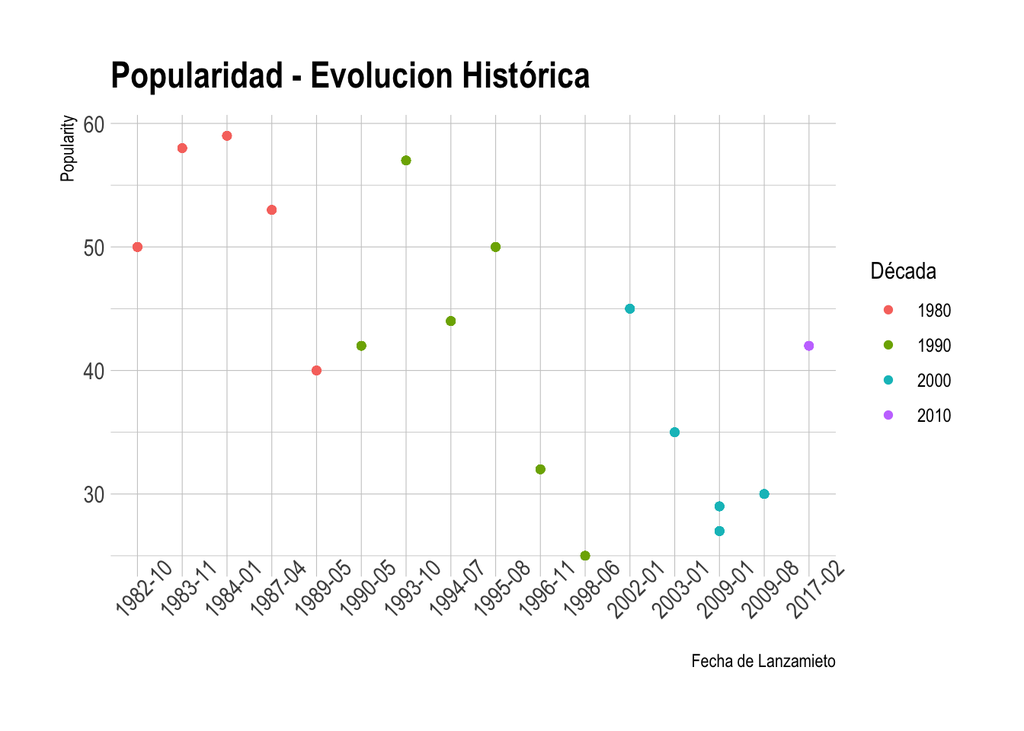

```r
df_unificado %>%
  filter(solista.banda == "solista") %>%
  mutate(release_date = str_sub(
                          string = release_date,
                          start = 1,
                          end = -4
                        )) %>%
  ggplot(aes(x=release_date, y=popularity, color = as.factor(decada))) +
  geom_point() +
  theme_ipsum() +
  labs(color = "Década")+
  xlab("Fecha de Lanzamieto") +
  ylab("Popularity")+
  theme(axis.text.x = element_text(angle = 45))+
  ggtitle("Popularidad - Evolucion Histórica")
```

Si realizamos un análisis por década se observa que en los inicios en la década de los 80 sus discos tenian mayor popularidad que al pasar las décadas fue disminuyendo. Una observación “rara” es que cada vez que comienza una década, el primer album tiene mas popularidad que el ultimo de la década anterior.

## Loudness Vs Energy

Loudness : Es el volumen general de una pista en decibelios (dB). Los valores de sonoridad se promedian en toda la pista y son útiles para comparar la sonoridad relativa de las pistas. El volumen es la cualidad de un sonido que es el principal correlato psicológico de la fuerza física (amplitud). Los valores típicos oscilan entre -60 y 0 db.

Energy : La energía es una medida de 0,0 a 1,0 y representa una medida perceptiva de intensidad y actividad. Por lo general, las pistas enérgicas se sienten rápidas, fuertes y ruidosas. Por ejemplo, el death metal tiene mucha energía, mientras que un preludio de Bach tiene una puntuación baja en la escala. Las características perceptivas que contribuyen a este atributo incluyen el rango dinámico, el volumen percibido, el timbre, la tasa de inicio y la entropía general.

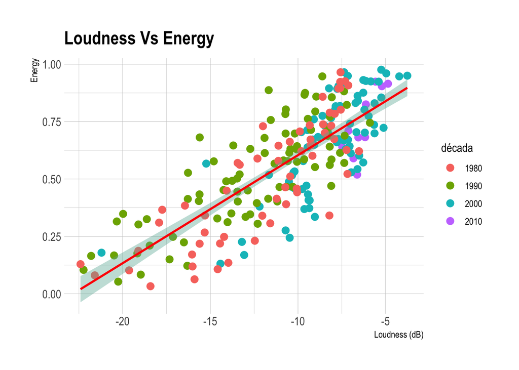

```r
df_unificado %>%
  filter(solista.banda == "solista") %>%
  ggplot(aes(x=loudness, y=energy, color = as.factor(decada))) +
  geom_point(size=3) +
  geom_smooth(method=lm , color="red", fill="#69b3a2", se=TRUE) +
  theme_ipsum()+
  labs(color = "década")+
  xlab("Loudness (dB)") +
  ylab("Energy")+
  ggtitle("Loudness Vs Energy")
```

Realizando una comparación con la vida de Charly y sus vaivenes emocionales, observamos que al inicio de su carrera como solista, y ya consolidado como RockStar, muestra canciones con fuerza media (color rojo). Luego en la década del 90, con el agravamiento de sus adicciones, las canciones tienden a bajar de intensidad.(color verde). Después de su recuperación de sus problemas de salud, regresó con temas de gran impacto (colores azul y violeta).

## Danceability

“Bailabilidad”. Medida entre 0 y 1, describe si la canción es adecuada para bailar (no = 0, sí = 1) de acuerdo a características musicales como tempo, estabilidad rítmica, fuerza del pulso, etc.

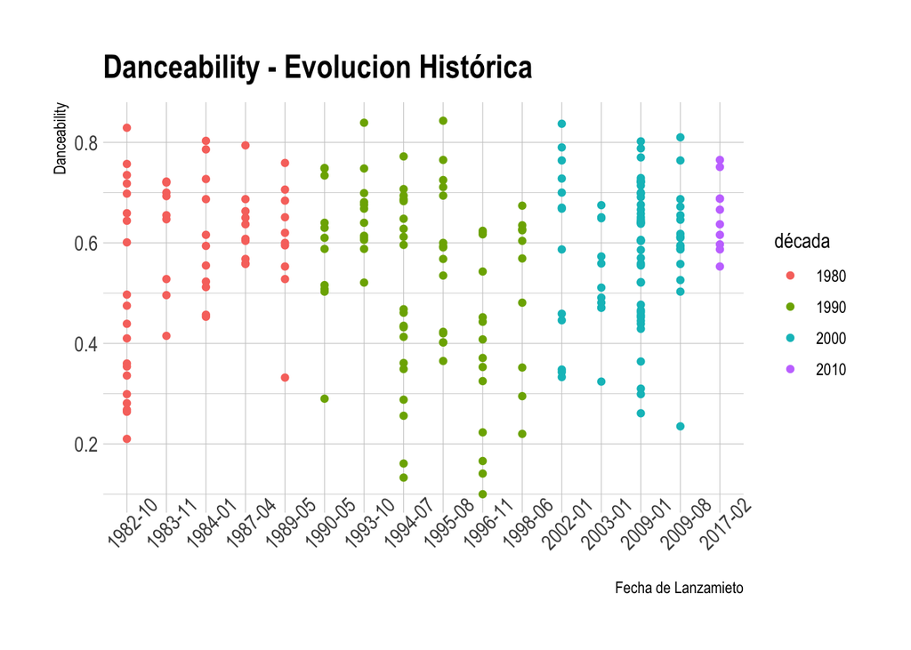

```r
df_unificado %>%
  filter(solista.banda == "solista") %>%
  mutate(release_date = str_sub(
                          string = release_date,
                          start = 1,
                          end = -4
                        )) %>%
  ggplot(aes(x=release_date, y=danceability, color = as.factor(decada))) +
  geom_point() +
  theme_ipsum()+
  labs(color = "década")+
  xlab("Fecha de Lanzamieto") +
  ylab("Danceability")+
  theme(axis.text.x = element_text(angle = 45))+
  ggtitle("Danceability - Evolucion Histórica")
```

**Conclusión:** Se analizan la bailabilidad de las canciones en las distintas décadas. Su comienzo es de baja intensidad en las canciones con temas más lentos, y crecen a través de los años. A mediados de la década el 90 se nota el regreso a las canciones menos intensas, volviendo a regresar con mucha fuerza en los últimos años.

## Speechiness

Es la locuacidad detecta la presencia de palabras habladas en una pista. Cuanto más exclusivamente hablada sea la grabación (por ejemplo, un programa de entrevistas, un audiolibro, poesía), más se acercará a 1,0 el valor del atributo. Los valores superiores a 0,66 describen pistas que probablemente estén compuestas en su totalidad por palabras habladas. Los valores entre 0,33 y 0,66 describen pistas que pueden contener tanto música como voz, ya sea en secciones o en capas, incluyendo casos como la música rap. Los valores inferiores a 0,33 representan probablemente música y otras pistas no habladas.

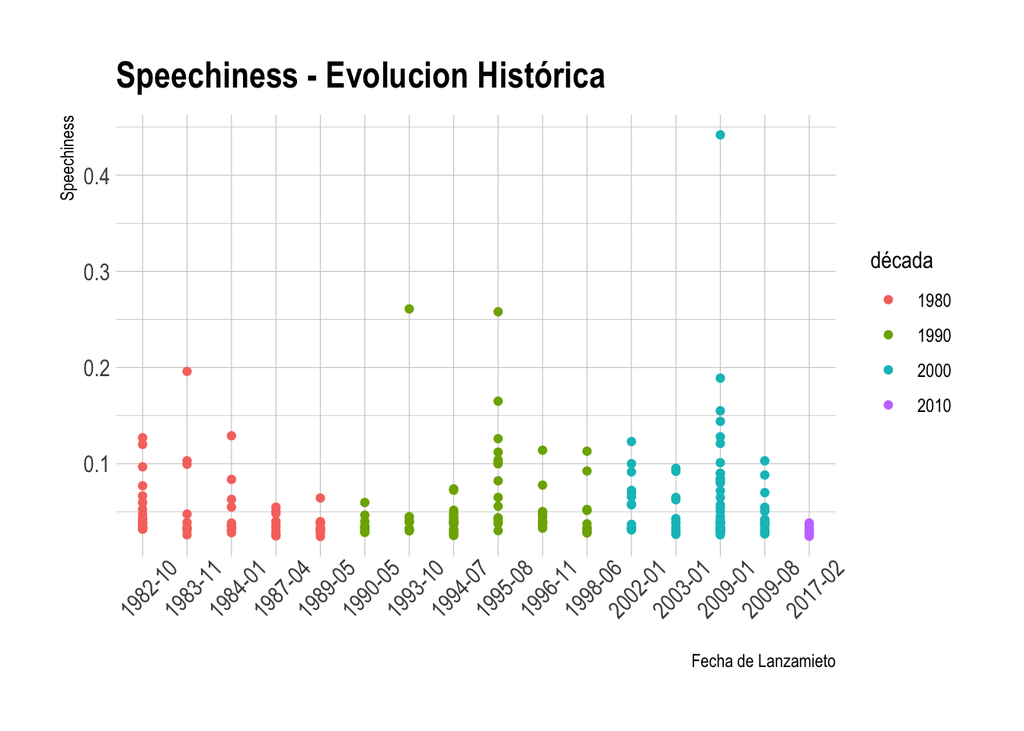

```r
#message=FALSE, warning=FALSE}
df_unificado %>%
  filter(solista.banda == "solista") %>%
  mutate(release_date = str_sub(
                          string = release_date,
                          start = 1,
                          end = -4
                        )) %>%
  ggplot(aes(x=release_date, y=speechiness, color = as.factor(decada))) +
  geom_point() +
  theme_ipsum()+
  labs(color = "década")+
  xlab("Fecha de Lanzamieto") +
  ylab("Speechiness")+
  theme(axis.text.x = element_text(angle = 45, margin = margin(t = 10, r = 0, b = 0, l = 0)))+
  ggtitle("Speechiness - Evolucion Histórica")
```

Para hacer un zoom al gráfico, nos quedamos con valores de Speechiness menores a 0.15 (`speechiness <= 0.15`). Otra opción podría haber sido cambiar la escala del gráfico en lugar de aplicar un filtro al set de datos.

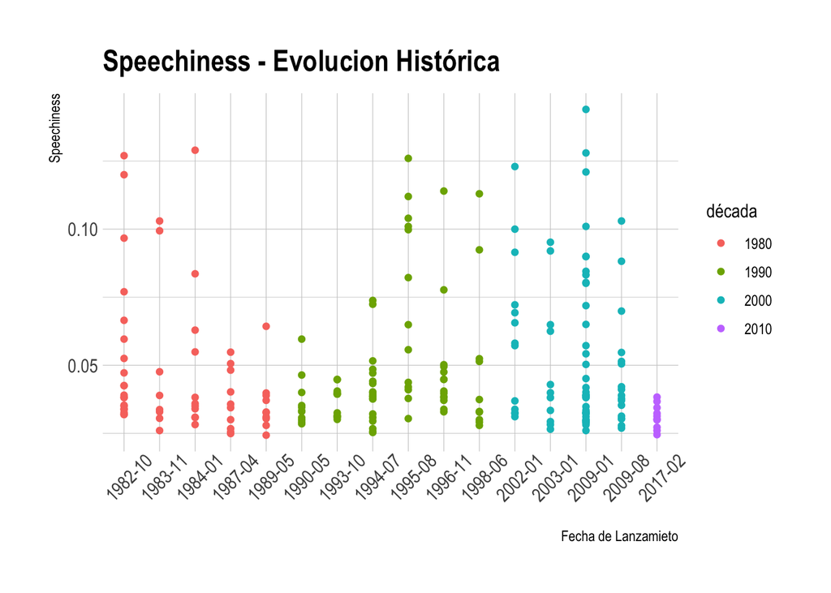

```r
#message=FALSE, warning=FALSE}
df_unificado %>%
  filter(solista.banda == "solista" & speechiness <= 0.15) %>%
  mutate(release_date = str_sub(
                          string = release_date,
                          start = 1,
                          end = -4
                        )) %>%
  ggplot(aes(x=release_date, y=speechiness, color = as.factor(decada))) +
  geom_point() +
  theme_ipsum()+
  labs(color = "década")+
  xlab("Fecha de Lanzamieto") +
  ylab("Speechiness")+
  theme(axis.text.x = element_text(angle = 45, margin = margin(t = 10, r = 0, b = 0, l = 0)))+
  ggtitle("Speechiness - Evolucion Histórica")
```

## Mejores temas

Los temas seleccionados fueron:

1. **Yendo de la cama al living** del album “Inconsciente colectivo” del año 1982
2. **Filosofía barata y zapatos de goma** del album “Filosofía barata y zapatos de goma” del año 1990
3. **Influencia** del album “Tu vicio” del año 2002.

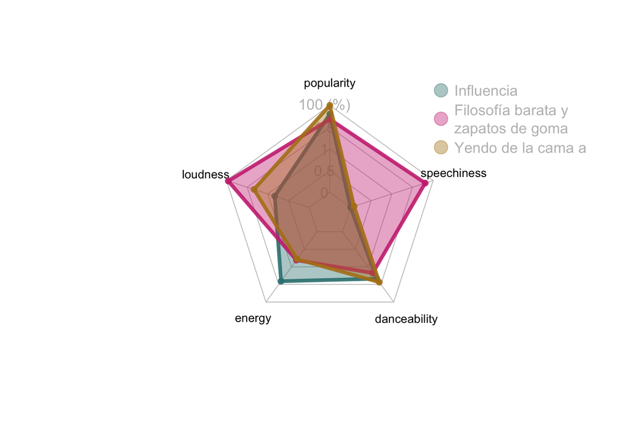

```r
#1. “Inconsciente colectivo” (Yendo de la cama al living 1982) => 13tz2i3p3x2dMK9906nVFk
#35. “Filosofía barata y zapatos de goma” (Filosofía barata y zapatos de goma, 1990) => 03mG8gRIri8ZO92bYmcERo
#32. “Tu vicio” (Influencia, 2002) => 7B8W8kfQwcVubGo2EGosID - 6C9f7KlcEcshGFYNgqjd0q

library(fmsb)
data <- df_unificado %>%
  filter(id %in% c("13tz2i3p3x2dMK9906nVFk", "03mG8gRIri8ZO92bYmcERo", "7B8W8kfQwcVubGo2EGosID")) %>%
  mutate(popularity = ((popularity)/100),
         danceability = ( as.numeric(danceability)),
         energy = ( as.numeric(energy)),
         speechiness = (100*(instrumentalness)),
         loudness = (-1 * as.numeric(loudness)/10)
  ) %>%
  select(id, popularity, loudness, energy, danceability, speechiness)

data <- rbind(data.frame(id = c(1,0),
           popularity = c(0.5,0),
           loudness = c(1.6,0),
           energy = c(1,0),
           danceability = c(1,0),
           speechiness = c(3,0)),
data)

data <- data[,2:6]
rownames(data) <- c("9","0","00","90","80")#data2[,1]

colors_border=c( rgb(0.2,0.5,0.5,0.9), rgb(0.8,0.2,0.5,0.9) , rgb(0.7,0.5,0.1,0.9) )
colors_in=c( rgb(0.2,0.5,0.5,0.4), rgb(0.8,0.2,0.5,0.4) , rgb(0.7,0.5,0.1,0.4) )
radarchart( data  , axistype=1 ,
            pcol=colors_border , pfcol=colors_in , plwd=4 , plty=1,
            cglcol="grey", cglty=1, axislabcol="grey", caxislabels=seq(0,1.5,0.5), cglwd=0.8,
            #custom labels
            vlcex=0.8
)
legend(x=0.9, y=1.4, legend = c("Influencia", "Filosofía barata y \nzapatos de goma", "Yendo de la cama al living"), bty = "n", pch=20 , col=colors_in , text.col = "grey", cex=1.0, pt.cex=3)
```

# Conclusión: